# “Bellabeat: Estrategia de Marketing impulsada por Datos de Smart Devices”

Betzy

2025-12-08

### 1. Configuración del Entorno y Carga de Datos

```r
##### Cargar librerías necesarias
library(tidyverse)
library(lubridate)

#### Carga de datos de actividad y sueño
daily_activity <- read.csv("dailyActivity_merged.csv")
sleep_day <- read.csv("sleepDay_merged.csv")

#### Estandarización y Limpieza de daily_activity
daily_activity <- daily_activity %>%
 rename(ID_Usuario = Id, Fecha_Actividad = ActivityDate) %>%
 mutate(Fecha_Actividad = mdy(Fecha_Actividad))

#### Estandarización y Limpieza de sleep_day
sleep_day <- sleep_day %>%
  rename(ID_Usuario = Id, Fecha_Sueño = SleepDay) %>%
  mutate(Fecha_Sueño = as.Date(mdy_hms(Fecha_Sueño)))

##### Unión de datos (left_join)
datos_analisis_diario <- daily_activity %>%
  left_join(sleep_day, by = c("ID_Usuario", "Fecha_Actividad" = "Fecha_Sueño"))
```

### 2. Análisis Exploratorio y Segmentación de Marketing

```r
#### 1. Cálculo de la disponibilidad de datos
analisis_disponibilidad <- datos_analisis_diario %>%
  summarise(tota_registros = n(),
            registros_con_sueño = sum(!is.na(TotalMinutesAsleep)),
            Porcentaje_Con_Sueno_Final = (registros_con_sueño / n()) * 100
)

print(analisis_disponibilidad)
```

```
##   tota_registros registros_con_sueño Porcentaje_Con_Sueno_Final
## 1            943                 413                   43.79639
```

```r
##### 2. Resumen por usuario y segmentación
resumen_usuario <- datos_analisis_diario %>%
  group_by(ID_Usuario) %>%
  summarise(
    dias_activos = n(),
    pasos_promedio = mean(TotalSteps, na.rm = TRUE),
    minutos_sedentarios_promedio = mean(SedentaryMinutes, na.rm = TRUE),
    minutos_activos_promedio = mean(VeryActiveMinutes + FairlyActiveMinutes, na.rm = TRUE),
    sueño_promedio_minutos = mean(TotalMinutesAsleep, na.rm = TRUE),
    tiempo_en_cama_promedio = mean(TotalTimeInBed, na.rm = TRUE)
) %>%
  mutate(
    tipo_usuario = case_when(
      pasos_promedio >= 7500 ~ "Activo_Diario",
      pasos_promedio >= 5000 ~ "Moderadamente Activo",
      TRUE ~ "Sedentario_Poco_Activo"
))
```

### Visualizaciones de Hallazgos Clave

### Gráfico 1: Distribución por Segmentos

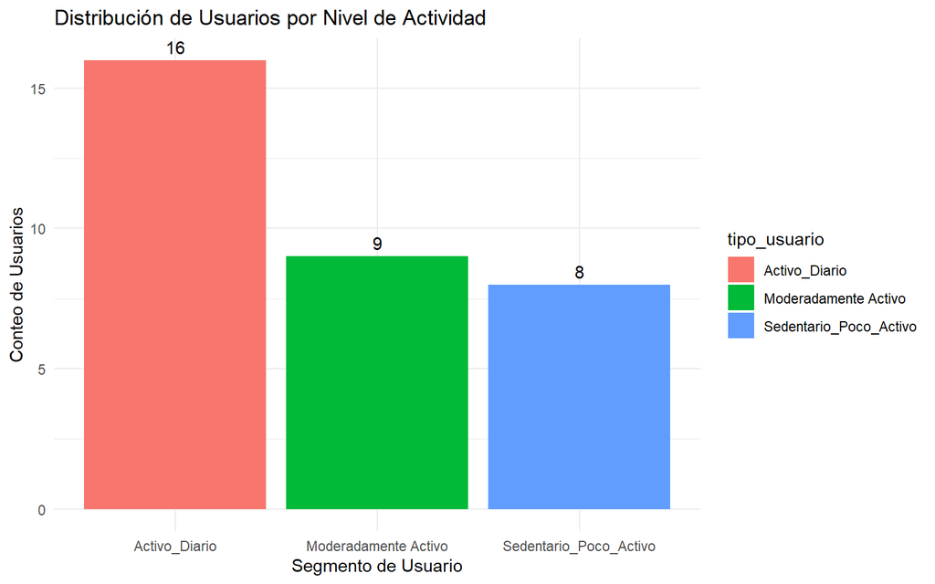

```r
plot_segmentacion <- ggplot(data = resumen_usuario, aes(x = tipo_usuario, fill = tipo_usuario)) +
  geom_bar() +
  labs(
    title = "Distribución de Usuarios por Nivel de Actividad",
    x = "Segmento de Usuario",
    y = "Conteo de Usuarios"
) +
  geom_text(stat='count', aes(label=..count..), vjust=-0.5) +
  theme_minimal()
print(plot_segmentacion)
```

### Gráfico 2: Eficiencia del Sueño

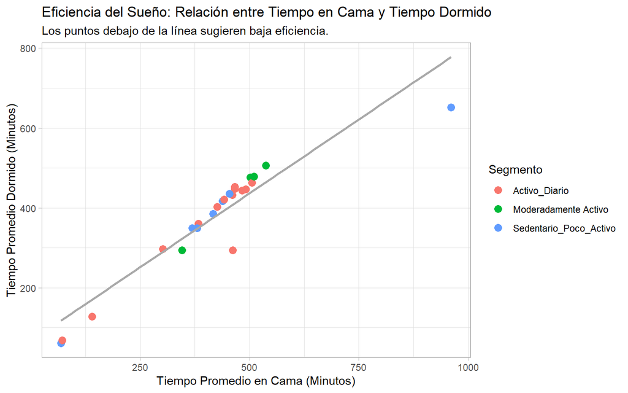

```r
plot_sueno <- resumen_usuario %>%
  filter(!is.na(sueño_promedio_minutos)) %>%
  ggplot(aes(x = tiempo_en_cama_promedio, y = sueño_promedio_minutos)) +
  geom_point(aes(color = tipo_usuario), size = 3) +
  geom_smooth(method = "lm", se = FALSE, color = "darkgrey") +
  labs(
    title = "Eficiencia del Sueño: Relación entre Tiempo en Cama y Tiempo Dormido",
    subtitle = "Los puntos debajo de la línea sugieren baja eficiencia.",
    x = "Tiempo Promedio en Cama (Minutos)",
    y = "Tiempo Promedio Dormido (Minutos)",
    color = "Segmento"
) +
  theme_light()
print(plot_sueno)
```

### Hallazgos Clave del Análisis

### 1. Sesgo de la Muestra e Inconsistencia de Datos

El análisis de disponibilidad de datos revela una limitación clave en la muestra:

Solo el **43.8%** de los días de actividad registrados tienen datos de sueño asociados.

- **Implicación:** La mayoría de los usuarios son **inconsistentes** en el uso del rastreador de sueño. Esto crea una oportunidad para que Bellabeat enfatice la **importancia de la consistencia** en el registro del sueño a través de recordatorios en la *app*.

### 2. Segmentación y Tendencia de Uso (Gráfico 1)

El análisis de pasos promedio clasifica a la base de usuarios de la siguiente manera:

| Segmento de Usuario | Conteo | Porcentaje | Pasos Promedio |
| --- | --- | --- | --- |
| **Activo Diario** | 16 | 48.5% | $\ge 7500$ pasos |
| **Moderadamente Activo** | 9 | 27.3% | $5000 - 7499$ pasos |
| **Sedentario/Poco Activo** | 8 | 24.2% | $< 5000$ pasos |

- **Implicación:** El grupo **Activo Diario** es el más grande. Esta tendencia indica que los usuarios de *wearables* están **altamente comprometidos**, haciendo de la **fidelización** (*up-selling*) el principal objetivo de marketing.

### 3. Eficiencia del Sueño (Gráfico 2)

El gráfico de dispersión (Tiempo en Cama vs. Tiempo Dormido) muestra una fuerte correlación, pero también revela una oportunidad de calidad:

- **Oportunidad de Calidad:** Los puntos que caen **significativamente por debajo de la línea de tendencia** (indicadores de baja eficiencia) demuestran que algunos usuarios pasan mucho tiempo en la cama, pero no duermen eficientemente.
- **Implicación:** Existe una clara necesidad de herramientas que ayuden a los usuarios a mejorar la **calidad del sueño**, justificando el valor de la **Membresía Bellabeat**.

### Conclusiones y Recomendaciones

### Conclusión Principal

La estrategia de marketing de Bellabeat debe evolucionar de un enfoque único a un **enfoque de marketing altamente segmentado**. La mayor oportunidad de crecimiento se encuentra en la **fidelización** (*up-selling*) y en la monetización a través de la membresía, dado que casi la mitad de la base de usuarios ya es activa (48.5%).

### Recomendaciones Estratégicas Clave

| Recomendación Estratégica | Segmento Objetivo | Contenido de Marketing | Producto Recomendado |
| --- | --- | --- | --- |
| **1. Fidelización y Monetización** | **Activo Diario** (48.5%) | Campañas enfocadas en el **rendimiento** y la **optimización** de los datos avanzados. | **Membresía de Suscripción** (para datos avanzados, meditación, nutrición para el sueño). |
| **2. Conversión Progresiva** | **Moderadamente Activo** (27.3%) | Campañas de **desafíos** (*gamification*), metas a corto plazo y el concepto de “elegancia funcional”. | **Bellabeat Time** (como un *upgrade* elegante que ofrece monitoreo constante). |
| **3. Motivación e Iniciación** | **Sedentario/Poco Activo** (24.2%) | Marketing de **concientización básica** sobre salud y la facilidad de uso del dispositivo. | **Bellabeat Leaf** (como una pieza de joyería atractiva y menos intimidante para empezar). |
| **4. Énfasis en el Valor del Sueño** | **Todos los Usuarios** | Contenido promocional sobre la **“eficiencia del sueño”** (el *gap* entre Tiempo en Cama y Tiempo Dormido). | **Membresía Bellabeat** (soluciones para mejorar la eficiencia del sueño). |